# Structuring around exemplars - ESIDA workshop

Joris Falip

12/2018

# Setup

This section highlights how to install the needed packages using two methods, then download et read the datasets used

### Packages

You can install every needed package by hand, or run one of the two following chunks. Those two chunks won’t run by default, you need to change *eval* to *TRUE*.

##### Checkpoint

This package is the best solution for reproducibility. It will install every needed package in the same version that was available on the day the analysis was done. This process takes a long time. Before running this chunk, you need to install the *checkpoint* package then create a *.checkpoint* folder inside the folder containing this Rmarkdown file.

```r
library(checkpoint)
checkpoint("2018-12-17")
```

##### Automagic

This package installs (using *install.packages()*) the missing packages, avoiding the hassle of installing packages one by one. Before running this chunk, you need to install the *automagic* package and set your current working directory to the folder containing this Rmd file.

```r
library(automagic)
#automagic()
```

We can now load the required packages and the proposed structuration algorithm.

```r
library(fields)
library(foreach)
library(doParallel)
library(magrittr)
library(ggpubr)
```

```r
library(ggplot2)
library(readxl)
library(readr)
library(purrr)
library(igraph)
library(igraph)

source("structuration.R")
```

We then download the two UCI datasets if they are not already in the data folder.

```r
if (!file.exists("./data/Residential-Building-Data-Set.xlsx")) {
  download.file("https://archive.ics.uci.edu/ml/machine-learning-databases/00437/Residential-Building-Data-Set.xlsx", "./data/Residential-Building-Data-Set.xlsx")
}

if (!file.exists("./data/CommViolPredUnnormalizedData.txt")) {
  download.file("http://archive.ics.uci.edu/ml/machine-learning-databases/00211/CommViolPredUnnormalizedData.txt", "./data/CommViolPredUnnormalizedData.txt")
}
```

We load the two UCI datasets and generate the synthethic dataset.

```r
if (params$dataset == "residential") {
  ### RESIDENTIAL ###
  # https://archive.ics.uci.edu/ml/datasets/Residential+Building+Data+Set

  housing <- read_excel("data/Residential-Building-Data-Set.xlsx",
                        sheet = "Data", col_names = FALSE, col_types = c("blank",
                                                                         "blank", "blank", "blank", "numeric",
                                                                         "numeric", "numeric", "numeric",
                                                                         "numeric", "numeric", "numeric",
                                                                         "numeric", "numeric", "numeric",
                                                                         "numeric", "numeric", "numeric",
                                                                         "numeric", "numeric", "numeric",
                                                                         "numeric", "numeric", "numeric",
                                                                         "numeric", "numeric", "numeric",
                                                                         "numeric", "numeric", "numeric",
                                                                         "numeric", "numeric", "numeric",
                                                                         "numeric", "numeric", "numeric",
                                                                         "numeric", "numeric", "numeric",
                                                                         "numeric", "numeric", "numeric",
                                                                         "numeric", "numeric", "numeric",
                                                                         "numeric", "numeric", "numeric",
                                                                         "numeric", "numeric", "numeric",
                                                                         "numeric", "numeric", "numeric",
                                                                         "numeric", "numeric", "numeric",
                                                                         "numeric", "numeric", "numeric",
                                                                         "numeric", "numeric", "numeric",
                                                                         "numeric", "numeric", "numeric",
                                                                         "numeric", "numeric", "numeric",
                                                                         "numeric", "numeric", "numeric",
                                                                         "numeric", "numeric", "numeric",
                                                                         "numeric", "numeric", "numeric",
                                                                         "numeric", "numeric", "numeric",
                                                                         "numeric", "numeric", "numeric",
                                                                         "numeric", "numeric", "numeric",
                                                                         "numeric", "numeric", "numeric",
                                                                         "numeric", "numeric", "numeric",
                                                                         "numeric", "numeric", "numeric",
                                                                         "numeric", "numeric", "numeric",
                                                                         "numeric", "numeric", "numeric",
                                                                         "numeric", "numeric", "numeric",
                                                                         "numeric", "numeric", "numeric",
                                                                         "numeric", "numeric"), skip = 2)

  data <- as.matrix(housing)
  soluce <- data[ ,105]
  data <- data[ ,-105]
  data <- data[ ,-104]

  rm(housing)
}
```

```
## `col_type = "blank"` deprecated. Use "skip" instead.
```

```r
if (params$dataset == "communities") {
  ### CRIME ###
  # http://archive.ics.uci.edu/ml/datasets/Communities+and+Crime+Unnormalized

  crime <- read_csv("data/CommViolPredUnnormalizedData.txt", col_names = FALSE, na = "?")

  data <- crime[ ,-c(1:5)]
  data <- as.matrix(data)
  soluce <- crime$X131
  data <- data[ ,1:124]
  colToKeep <- colSums(is.na(data)) > 0
  data <- data[ ,!colToKeep]

  rm(crime,colToKeep)
}

if (params$dataset == "norm") {
  ### SYNTHETHIC ###

  data <- matrix(0, ncol = 1000, nrow = 300)
  set.seed(2019)
  for (norm in 1:800) {
    data[, norm] <- rnorm(300, mean = 0, sd = 1)
  }
  for (unif in 801:1000) {
    data[, unif] <- runif(300, 0, 1)
  }
}
```

# Analysis

To start the analysis, the *dataset* and *k* parameters are required, in the header of this Rmd file. *dataset* can take the following values : “residential” for the Residential Building dataset, “communities” for the Communities and Crime dataset, and “norm” for the synthethic dataset using normal distributions and uniform distributions. *threshold* parameter of this script is the threshold *T* for formula 1 of the article.

The following chunk run the proposed exemplar and structures elements around exemplars. It then displays the structure as a graph, and compute the number of connected components, their size and mean diameter.

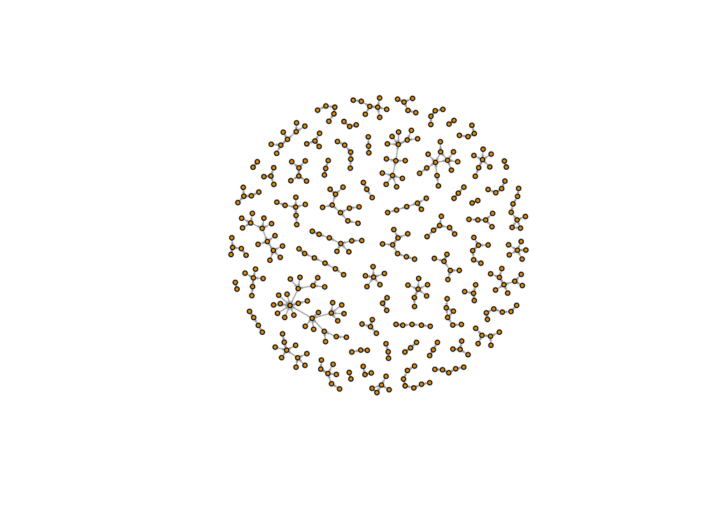

```r
results_exemplars <- structuration(data, params$k, params$threshold)
exemplars_graph <- make_graph(as.vector(rbind(1:length(results_exemplars), results_exemplars)))
plot(exemplars_graph, vertex.size = 3, edge.arrow.size = 0.1, vertex.label = "")
```

```r
components(exemplars_graph)$no
```

```
## [1] 64
```

```r
mean(components(exemplars_graph)$csize)
```

```
## [1] 5.8125
```

```r
mean(unlist(lapply(decompose(exemplars_graph), diameter)))
```

```
## [1] 2.703125
```

We create a similar structure by linking each element ot its closest neighbor using a minkowski distance of order 0.75. We extract the same information regarding connected components.

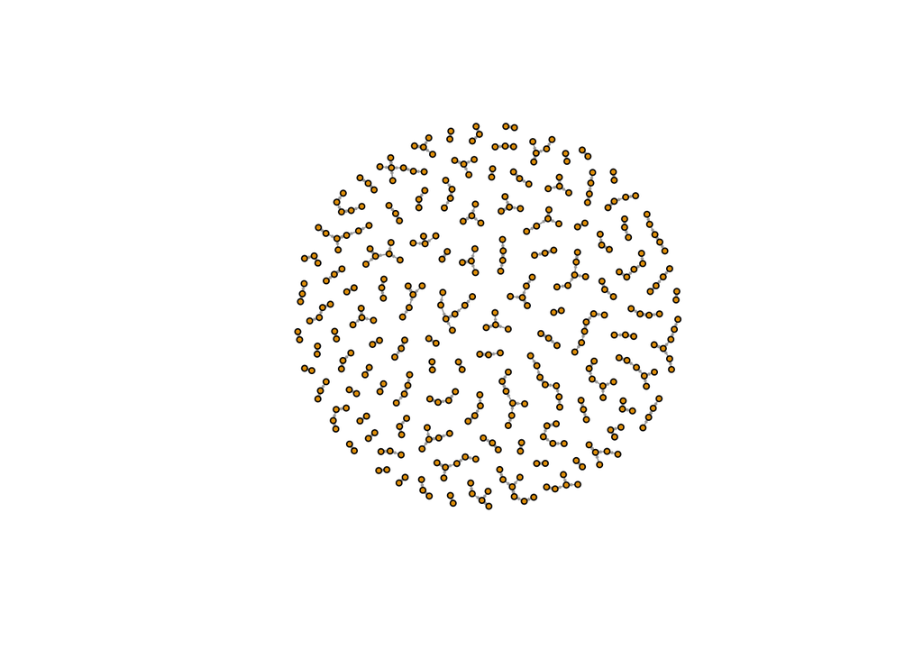

```r
distance_matrix <- as.matrix(dist(scale(data), method = "minkowski", p = 0.75))
results_minkowski <- integer(dim(data)[1])
diag(distance_matrix) <- 9999999
for (elem in 1:dim(data)[1]) {
  results_minkowski[elem] <- which(distance_matrix[elem,] == min(distance_matrix[elem,]))
}

mink_graph <- make_graph(as.vector(rbind(1:dim(data)[1], results_minkowski)))
plot(mink_graph, vertex.size = 3, edge.arrow.size = 0.1, vertex.label = "")
```

```r
components(mink_graph)$no
```

```
## [1] 104
```

```r
mean(components(mink_graph)$csize)
```

```
## [1] 3.576923
```

```r
mean(unlist(lapply(decompose(mink_graph), diameter)))
```

```
## [1] 2.096154
```

This chunk generates a chart displaying the number of connected components of the resulting structure, for every value of the input paramter *k* ranging from 1 to input parameter *range*. This code is executed in a multithreaded fashion, using as many cores as specified by parameter *nb_cpus*.

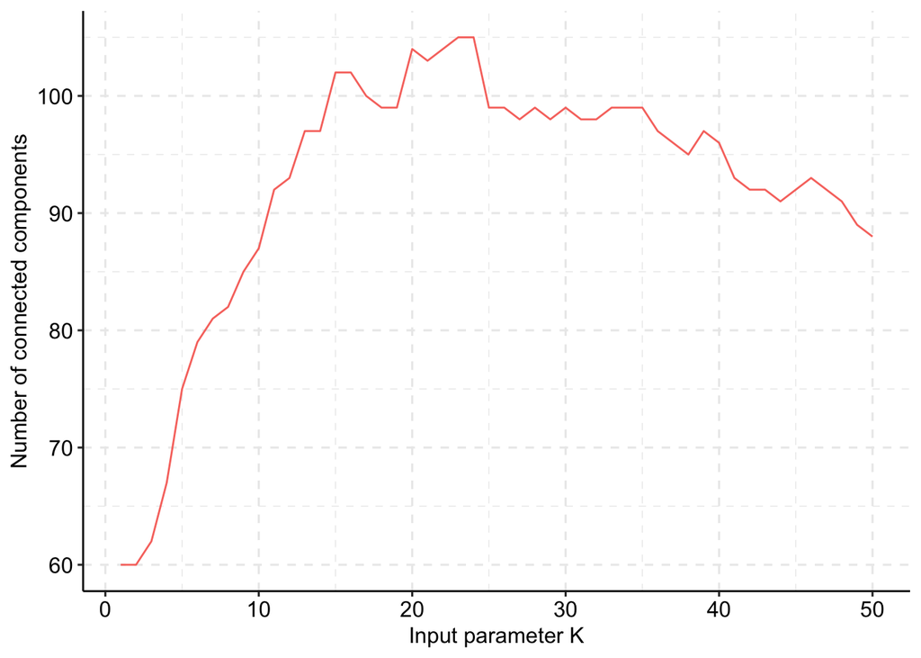

```r
registerDoParallel(params$nb_cpus)

composantes <- foreach(i = 1:params$range) %dopar% {
  results_components <- structuration(data, i, params$threshold)

  resgraph <- make_graph(as.vector(rbind(seq_len(dim(data)[1]), results_components)))
  return(components(resgraph)$no)
}

composantes <- unlist(composantes)
df <- as.data.frame(composantes)

composantes_graphs <- ggplot(df, aes(1:params$range)) +
  geom_line(aes(y = composantes, color = "")) +
  labs(x = "Input parameter K", y = "Number of connected components")
composantes_graphs + theme_pubr() + grids(linetype = "dashed") + theme(legend.position = "none")
```

```r
stopImplicitCluster()
```